# Featurization, Model Selection & Tuning - Concrete Strength regression

## Import Libraries and load data

```python
import numpy as np
import pandas as pd
import matplotlib.pyplot as plt
%matplotlib inline
import seaborn as sns
sns.set(color_codes=True)
from sklearn.impute import SimpleImputer
from scipy.stats import zscore
from sklearn.decomposition import PCA
from sklearn.model_selection import train_test_split
from sklearn.cluster import KMeans
from sklearn.linear_model import LinearRegression, Lasso, Ridge
from sklearn.svm import SVR
from sklearn.tree import DecisionTreeRegressor
from sklearn.ensemble import RandomForestRegressor, BaggingRegressor, AdaBoostRegressor, GradientBoostingRegressor
from sklearn.model_selection import GridSearchCV, cross_val_score
import warnings
warnings.filterwarnings('ignore')
```

```python
dataset = pd.read_csv("concrete.csv")
dataset.head()
```

|  | cement | slag | ash | water | superplastic | coarseagg | fineagg | age | strength |
| --- | --- | --- | --- | --- | --- | --- | --- | --- | --- |
| 0 | 141.3 | 212.0 | 0.0 | 203.5 | 0.0 | 971.8 | 748.5 | 28 | 29.89 |
| 1 | 168.9 | 42.2 | 124.3 | 158.3 | 10.8 | 1080.8 | 796.2 | 14 | 23.51 |
| 2 | 250.0 | 0.0 | 95.7 | 187.4 | 5.5 | 956.9 | 861.2 | 28 | 29.22 |
| 3 | 266.0 | 114.0 | 0.0 | 228.0 | 0.0 | 932.0 | 670.0 | 28 | 45.85 |
| 4 | 154.8 | 183.4 | 0.0 | 193.3 | 9.1 | 1047.4 | 696.7 | 28 | 18.29 |

## Exploratory Data Analysis

### Univariate Analysis

```python
#### Shape of the data
print("The data has {} rows and {} columns".format(dataset.shape[0], dataset.shape[1]))
```

```
The data has 1030 rows and 9 columns
```

```python
#### Look out for Duplicates in the dataset
dataset.duplicated().values.any()
```

```
True
```

There are duplicate values in the dataset that we need to remove.

```python
dataset = dataset.drop_duplicates()
```

```python
#### Shape of the data
print("The data now has {} rows and {} columns".format(dataset.shape[0], dataset.shape[1]))
```

```
The data now has 1005 rows and 9 columns
```

We have dropped 25 duplicate rows

```python
#### Exploring column information and data types
dataset.info()
```

```
<class 'pandas.core.frame.DataFrame'>
Int64Index: 1005 entries, 0 to 1029
Data columns (total 9 columns):
 #   Column        Non-Null Count  Dtype
---  ------        --------------  -----
 0   cement        1005 non-null   float64
 1   slag          1005 non-null   float64
 2   ash           1005 non-null   float64
 3   water         1005 non-null   float64
 4   superplastic  1005 non-null   float64
 5   coarseagg     1005 non-null   float64
 6   fineagg       1005 non-null   float64
 7   age           1005 non-null   int64
 8   strength      1005 non-null   float64
dtypes: float64(8), int64(1)
memory usage: 78.5 KB
```

"strength" is the dependent variable here.

#### Five point summary

```python
dataset.describe().T
```

|  | count | mean | std | min | 25% | 50% | 75% | max |
| --- | --- | --- | --- | --- | --- | --- | --- | --- |
| cement | 1005.0 | 278.631343 | 104.344261 | 102.00 | 190.70 | 265.0 | 349.00 | 540.0 |
| slag | 1005.0 | 72.043483 | 86.170807 | 0.00 | 0.00 | 20.0 | 142.50 | 359.4 |
| ash | 1005.0 | 55.536318 | 64.207969 | 0.00 | 0.00 | 0.0 | 118.30 | 200.1 |
| water | 1005.0 | 182.075323 | 21.339334 | 121.80 | 166.60 | 185.7 | 192.90 | 247.0 |
| superplastic | 1005.0 | 6.033234 | 5.919967 | 0.00 | 0.00 | 6.1 | 10.00 | 32.2 |
| coarseagg | 1005.0 | 974.376816 | 77.579667 | 801.00 | 932.00 | 968.0 | 1031.00 | 1145.0 |
| fineagg | 1005.0 | 772.688259 | 80.340435 | 594.00 | 724.30 | 780.0 | 822.20 | 992.6 |
| age | 1005.0 | 45.856716 | 63.734692 | 1.00 | 7.00 | 28.0 | 56.00 | 365.0 |
| strength | 1005.0 | 35.250378 | 16.284815 | 2.33 | 23.52 | 33.8 | 44.87 | 82.6 |

#### Univariate plots

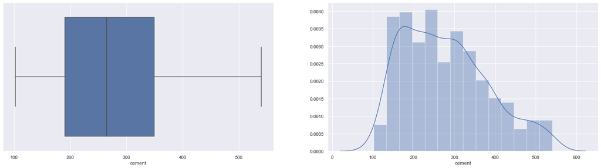

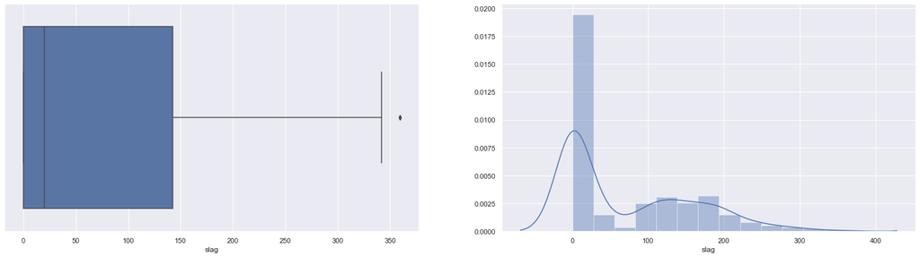

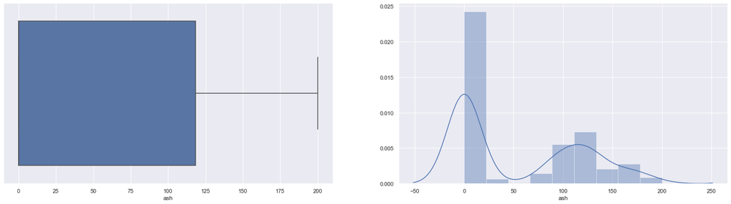

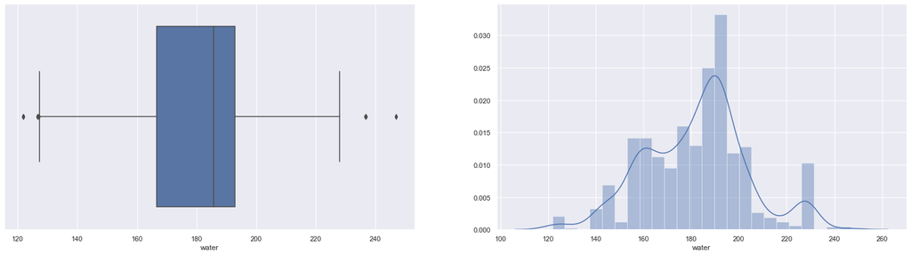

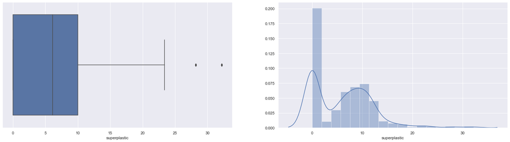

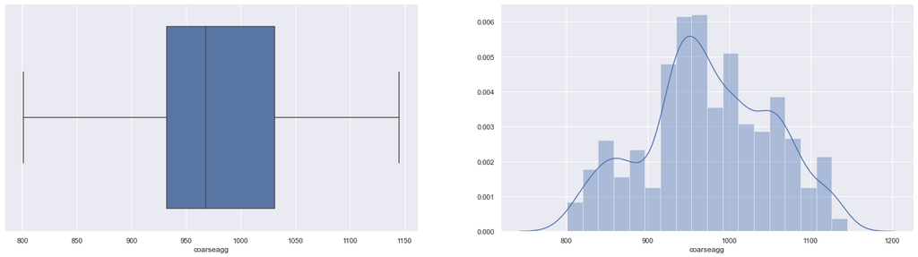

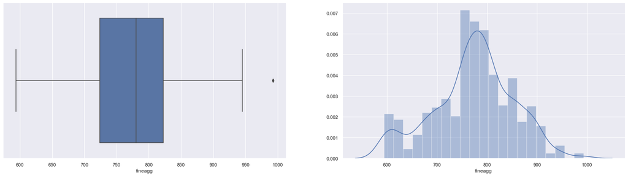

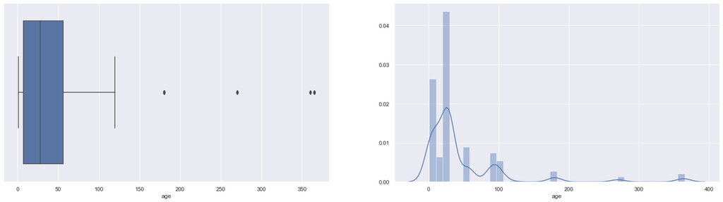

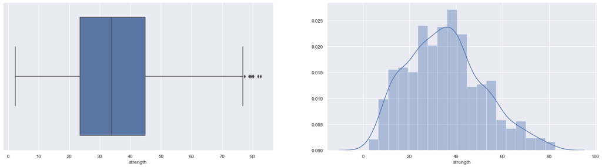

```python
def univariate_plots(Source):
    a = pd.Series(Source.select_dtypes(include=['float64','int64']).columns)
    leng = len(a)
    for j in range(0,len(a)):
        f, axes = plt.subplots(1, 2, figsize=(10, 10))
        sns.boxplot(Source[a[j]], ax = axes[0])
        sns.distplot(Source[a[j]], ax = axes[1])
        plt.subplots_adjust(top =  1.5, right = 10, left = 8, bottom = 1)

univariate_plots(dataset)
```

#### Bivariate Analysis

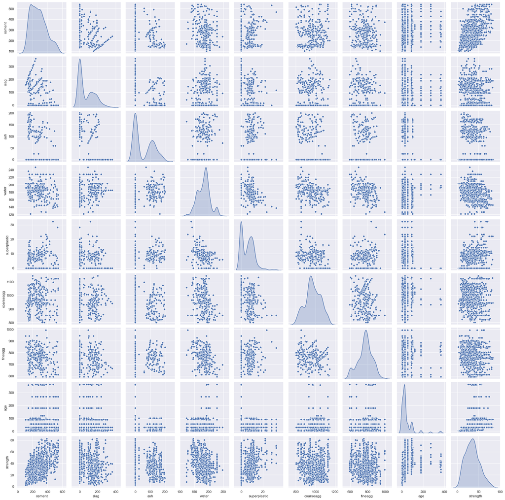

```python
sns.pairplot(dataset, diag_kind='kde')
```

There seem to be many features with Gaussian mixtures as shown in the kde plots

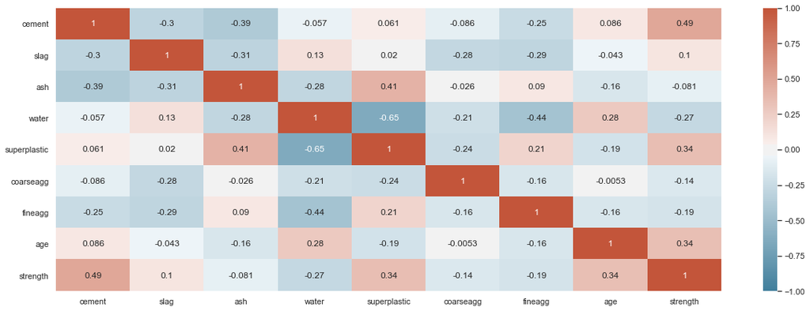

```python
def EDA_Corr(df):
        """This gives output as Covariance matrix and feature wise uniquess i.e how much its statistically
        independent. This is done with default range of corr between +0.5 to -0.6"""
        corr = df.corr()
        index = corr.columns
        Output = []
        for i in range(0,len(index)):
            i = index[i]
            Pos = corr.index[(corr[i] >= 0.5)].tolist()
            No = corr.index[(corr[i] < 0.5) & (corr[i] > -0.6)].tolist()
            Neg = corr.index[(corr[i] <= -0.5)].tolist()
            leng_u = len(No)
            leng_pos = len(Pos)
            leng_neg = len(Neg)
            Out = [i, leng_u, leng_pos, leng_neg, Pos, Neg, No]
            Output.append(Out)
        fig, ax = plt.subplots(figsize=(20,7))
        cmap = sns.diverging_palette(230, 20, as_cmap=True)
        sns.heatmap(corr,annot=True,vmin=-1,vmax=1,cmap=cmap, linewidths=0, ax = ax)
EDA_Corr(dataset)
```

From the pair plot and the Correlation matrix, it appears that there not a very significant correlation between various attributes. However,

- There appear to correlation between Superplastic and water
- There seem to be some correlation between water and fineagg
- There seem to be some correlation between cement and strength
- There seem to be some correlation between ash and superplastic

#### Imputation of missing values and outliers

```python
print(dataset.isna().values.any())
print(dataset.isnull().values.any())
```

```
False
False
```

```python
dataset[dataset.isna().values == True].shape
```

```
(0, 9)
```

No missing values, nothing to impute

```python
#### Checking outliers
cols = [i for i in dataset.columns if i != 'strength']
for col in cols:
    print('For column:', col)
    Q1=dataset[col].quantile(0.25)
    Q3=dataset[col].quantile(0.75)
    IQR=Q3-Q1
    Lower_Whisker = Q1-1.5*IQR
    Upper_Whisker = Q3+1.5*IQR

    print("Inter Quartie Range::",IQR)
    print(col, "above", Upper_Whisker,"and below", Lower_Whisker, "are outliers")
    print('-----------------------')
```

```
For column: cement
Inter Quartie Range:: 158.3
cement above 586.45 and below -46.75000000000003 are outliers
-----------------------
For column: slag
Inter Quartie Range:: 142.5
slag above 356.25 and below -213.75 are outliers
-----------------------
For column: ash
Inter Quartie Range:: 118.3
ash above 295.75 and below -177.45 are outliers
-----------------------
For column: water
Inter Quartie Range:: 26.30000000000001
water above 232.35000000000002 and below 127.14999999999998 are outliers
-----------------------
For column: superplastic
Inter Quartie Range:: 10.0
superplastic above 25.0 and below -15.0 are outliers
-----------------------
For column: coarseagg
Inter Quartie Range:: 99.0
coarseagg above 1179.5 and below 783.5 are outliers
-----------------------
For column: fineagg
Inter Quartie Range:: 97.90000000000009
fineagg above 969.0500000000002 and below 577.4499999999998 are outliers
-----------------------
For column: age
Inter Quartie Range:: 49.0
age above 129.5 and below -66.5 are outliers
-----------------------
```

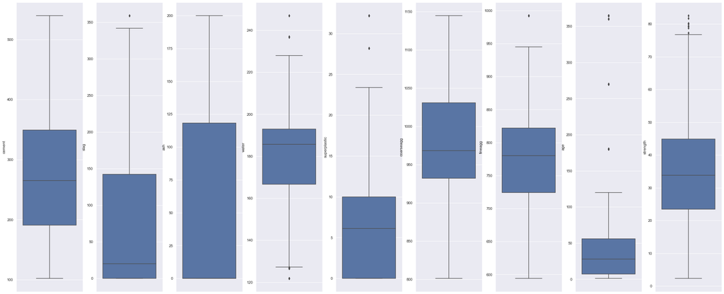

```python
a = pd.Series(dataset.select_dtypes(include=['float64','int64']).columns)
leng = len(a)
f, axes = plt.subplots(1, leng, figsize=(38,16))
for j in range(0,len(a)):
    sns.boxplot(dataset[a[j]], ax = axes[j], orient='v')
```

slag, water, superplastic, fineagg and age have outliers

##### Treating ouliers

We will be opting for a strategy of replacing the outliers by NaN and then imputing NA values with medians

```python
for col in cols:
    Q1=dataset[col].quantile(0.25)
    Q3=dataset[col].quantile(0.75)
    IQR=Q3-Q1
    Lower_Whisker = Q1-1.5*IQR
    Upper_Whisker = Q3+1.5*IQR
    dataset[col][dataset[col]> Upper_Whisker] = np.nan
    dataset[col][dataset[col]< Lower_Whisker] = np.nan
```

```python
dataset.info()
```

```
<class 'pandas.core.frame.DataFrame'>
Int64Index: 1005 entries, 0 to 1029
Data columns (total 9 columns):
 #   Column        Non-Null Count  Dtype
---  ------        --------------  -----
 0   cement        1005 non-null   float64
 1   slag          1003 non-null   float64
 2   ash           1005 non-null   float64
 3   water         990 non-null    float64
 4   superplastic  995 non-null    float64
 5   coarseagg     1005 non-null   float64
 6   fineagg       1000 non-null   float64
 7   age           946 non-null    float64
 8   strength      1005 non-null   float64
dtypes: float64(9)
memory usage: 118.5 KB
```

```python
impute = SimpleImputer(strategy="median")
dataset[cols] = impute.fit_transform(dataset[cols])
```

```python
dataset.info()
```

```
<class 'pandas.core.frame.DataFrame'>
Int64Index: 1005 entries, 0 to 1029
Data columns (total 9 columns):
 #   Column        Non-Null Count  Dtype
---  ------        --------------  -----
 0   cement        1005 non-null   float64
 1   slag          1005 non-null   float64
 2   ash           1005 non-null   float64
 3   water         1005 non-null   float64
 4   superplastic  1005 non-null   float64
 5   coarseagg     1005 non-null   float64
 6   fineagg       1005 non-null   float64
 7   age           1005 non-null   float64
 8   strength      1005 non-null   float64
dtypes: float64(9)
memory usage: 118.5 KB
```

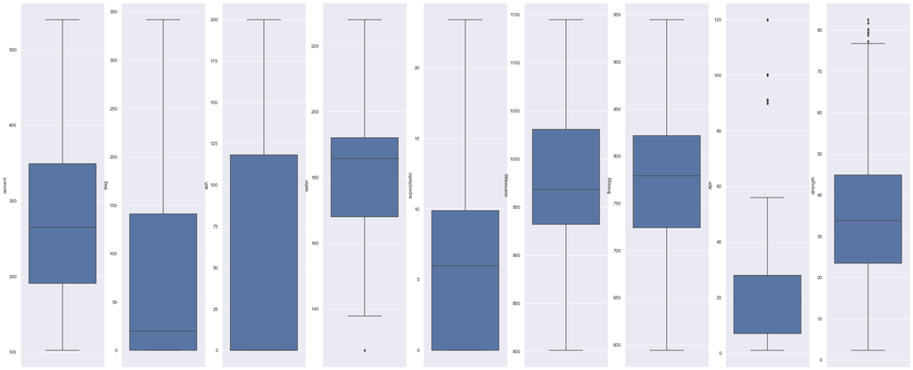

```python
def univariate_plots(Source):
    a = pd.Series(Source.select_dtypes(include=['float64','int64']).columns)
    leng = len(a)
    f, axes = plt.subplots(1, leng, figsize=(38,16))
    for j in range(0,len(a)):
        sns.boxplot(Source[a[j]], ax = axes[j], orient='v')

univariate_plots(dataset)
```

After imputing, there are some new outliers that crop up. But we need to accept them.

## Feature Engineering

### Identify opportunities (if any) to create a composite feature, drop a feature etc.

#### Composite feature creation

We can create a column with the ratio of water and cement since we know by experience that a right mixture of water and cement plays an importance role in the strength of the concrete

```python
dataset['water/cement'] = dataset['water']/dataset['cement']
```

```python
dataset.head()
```

|  | cement | slag | ash | water | superplastic | coarseagg | fineagg | age | strength | water/cement |
| --- | --- | --- | --- | --- | --- | --- | --- | --- | --- | --- |
| 0 | 141.3 | 212.0 | 0.0 | 203.5 | 0.0 | 971.8 | 748.5 | 28.0 | 29.89 | 1.440198 |
| 1 | 168.9 | 42.2 | 124.3 | 158.3 | 10.8 | 1080.8 | 796.2 | 14.0 | 23.51 | 0.937241 |
| 2 | 250.0 | 0.0 | 95.7 | 187.4 | 5.5 | 956.9 | 861.2 | 28.0 | 29.22 | 0.749600 |
| 3 | 266.0 | 114.0 | 0.0 | 228.0 | 0.0 | 932.0 | 670.0 | 28.0 | 45.85 | 0.857143 |
| 4 | 154.8 | 183.4 | 0.0 | 193.3 | 9.1 | 1047.4 | 696.7 | 28.0 | 18.29 | 1.248708 |

#### Dropping/deleting feature

For this we will be using the PCA for demensionality reduction.

```python
dataset_pca = dataset.copy()
dataset_pca_scaled = dataset_pca.apply(zscore)
dataset_pca_scaled.head()
```

|  | cement | slag | ash | water | superplastic | coarseagg | fineagg | age | strength | water/cement |
| --- | --- | --- | --- | --- | --- | --- | --- | --- | --- | --- |
| 0 | -1.316792 | 1.650657 | -0.865375 | 1.043488 | -1.073740 | -0.033232 | -0.293557 | -0.148903 | -0.329328 | 2.191929 |
| 1 | -1.052152 | -0.342358 | 1.071486 | -1.204851 | 0.928248 | 1.372475 | 0.311909 | -0.655204 | -0.721299 | 0.576284 |
| 2 | -0.274530 | -0.837677 | 0.625836 | 0.242642 | -0.054209 | -0.225388 | 1.136968 | -0.148903 | -0.370491 | -0.026473 |
| 3 | -0.121115 | 0.500389 | -0.865375 | 2.262168 | -1.073740 | -0.546508 | -1.289973 | -0.148903 | 0.651214 | 0.318986 |
| 4 | -1.187348 | 1.314966 | -0.865375 | 0.536120 | 0.613121 | 0.941736 | -0.951065 | -0.148903 | -1.042003 | 1.576807 |

```python
X_scaled_pca = dataset_pca_scaled.drop('strength', axis='columns')
X_scaled_pca.head()
```

|  | cement | slag | ash | water | superplastic | coarseagg | fineagg | age | water/cement |
| --- | --- | --- | --- | --- | --- | --- | --- | --- | --- |
| 0 | -1.316792 | 1.650657 | -0.865375 | 1.043488 | -1.073740 | -0.033232 | -0.293557 | -0.148903 | 2.191929 |
| 1 | -1.052152 | -0.342358 | 1.071486 | -1.204851 | 0.928248 | 1.372475 | 0.311909 | -0.655204 | 0.576284 |
| 2 | -0.274530 | -0.837677 | 0.625836 | 0.242642 | -0.054209 | -0.225388 | 1.136968 | -0.148903 | -0.026473 |
| 3 | -0.121115 | 0.500389 | -0.865375 | 2.262168 | -1.073740 | -0.546508 | -1.289973 | -0.148903 | 0.318986 |
| 4 | -1.187348 | 1.314966 | -0.865375 | 0.536120 | 0.613121 | 0.941736 | -0.951065 | -0.148903 | 1.576807 |

```python
covMatrix = np.cov(X_scaled_pca, rowvar=False)
```

```python
pca = PCA(n_components=8)
pca.fit(X_scaled_pca)
```

```
PCA(copy=True, iterated_power='auto', n_components=8, random_state=None,
  svd_solver='auto', tol=0.0, whiten=False)
```

```python
#Computing the eigen Values
print(pca.explained_variance_)
```

```
[2.23256106 2.21109068 1.3101226  1.02820024 0.98992516 0.90873634
 0.20471433 0.08724637]
```

```python
#Computing the eigen Vectors
print(pca.components_)
```

```
[[-5.75652278e-01  3.75908728e-01  8.12551998e-02  2.89243873e-01
  -1.46158008e-01 -9.90592654e-02 -7.30884248e-03 -3.11620623e-03
   6.37035813e-01]
 [-2.79995155e-01 -1.57141755e-01  5.06652267e-01 -4.85492387e-01
   4.87069098e-01  3.88149658e-03  3.81702517e-01  9.41079937e-02
   1.12717817e-01]
 [ 1.82355992e-01  5.19098265e-01 -7.39288108e-02 -5.78984575e-02
   4.42324498e-01 -6.75327526e-01 -1.32325490e-01 -8.28102809e-02
  -1.11264440e-01]
 [-2.00629743e-02  2.03523835e-01  2.90399008e-01 -7.18056004e-02
   2.72943997e-01  4.51719945e-01 -7.66589157e-01  4.62841528e-02
  -1.83685651e-02]
 [ 4.77796654e-02 -1.03212560e-02 -1.43886086e-04  1.27155516e-01
  -8.10006230e-03 -1.21608197e-01 -3.05932330e-02  9.82363812e-01
  -2.47640700e-02]
 [ 9.24857601e-02 -4.81373018e-01  5.55528805e-01  4.80989080e-01
  -9.91383548e-03 -3.98424839e-01 -2.11095376e-01 -1.27430360e-01
   1.11023405e-02]
 [-1.06092519e-01 -2.54157678e-01 -4.26142008e-01  4.69654240e-01
   6.82727050e-01  2.01242898e-01  8.81457145e-02 -2.29584980e-02
   8.40502678e-02]
 [ 4.87292307e-01 -2.48964796e-01 -1.70841205e-01 -2.98865075e-01
   3.73278175e-02 -8.18987879e-02 -1.67283754e-01  1.59252568e-02
   7.38726907e-01]]
```

```python
#Computing the explained var ration
print(pca.explained_variance_ratio_)
```

```
[0.24781551 0.24543229 0.14542433 0.1141308  0.10988224 0.10087024
 0.0227234  0.0096844 ]
```

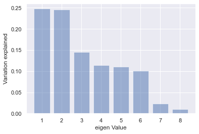

```python
plt.bar(list(range(1,9)),pca.explained_variance_ratio_,alpha=0.5, align='center')
plt.ylabel('Variation explained')
plt.xlabel('eigen Value')
plt.show()
```

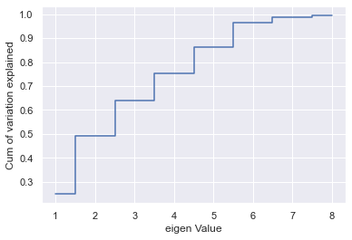

```python
plt.step(list(range(1,9)),np.cumsum(pca.explained_variance_ratio_), where='mid')
plt.ylabel('Cum of variation explained')
plt.xlabel('eigen Value')
plt.show()
```

```python
cum_var_exp = np.cumsum(pca.explained_variance_ratio_)
pd.DataFrame(cum_var_exp,columns=['Cumul Variance Explanation'],index=['1','2','3','4','5','6','7','8'])
```

|  | Cumul Variance Explanation |
| --- | --- |
| 1 | 0.247816 |
| 2 | 0.493248 |
| 3 | 0.638672 |
| 4 | 0.752803 |
| 5 | 0.862685 |
| 6 | 0.963555 |
| 7 | 0.986279 |
| 8 | 0.995963 |

The above plots and cumulative variance suggests that we need 6 features to explain over 95% of the variance in the dataset. Hence, we will take 6 components

```python
pca6 = PCA(n_components=6)
Xpca6 = pca6.fit_transform(X_scaled_pca)
y = dataset_pca_scaled['strength']
```

```python
#Computing the eigen Values
print(pca6.explained_variance_)
```

```
[2.23256106 2.21109068 1.3101226  1.02820024 0.98992516 0.90873634]
```

```python
#Computing the eigen Vectors
print(pca6.components_)
```

```
[[-5.75652278e-01  3.75908728e-01  8.12551998e-02  2.89243873e-01
  -1.46158008e-01 -9.90592654e-02 -7.30884248e-03 -3.11620623e-03
   6.37035813e-01]
 [-2.79995155e-01 -1.57141755e-01  5.06652267e-01 -4.85492387e-01
   4.87069098e-01  3.88149658e-03  3.81702517e-01  9.41079937e-02
   1.12717817e-01]
 [ 1.82355992e-01  5.19098265e-01 -7.39288108e-02 -5.78984575e-02
   4.42324498e-01 -6.75327526e-01 -1.32325490e-01 -8.28102809e-02
  -1.11264440e-01]
 [-2.00629743e-02  2.03523835e-01  2.90399008e-01 -7.18056004e-02
   2.72943997e-01  4.51719945e-01 -7.66589157e-01  4.62841528e-02
  -1.83685651e-02]
 [ 4.77796654e-02 -1.03212560e-02 -1.43886086e-04  1.27155516e-01
  -8.10006230e-03 -1.21608197e-01 -3.05932330e-02  9.82363812e-01
  -2.47640700e-02]
 [ 9.24857601e-02 -4.81373018e-01  5.55528805e-01  4.80989080e-01
  -9.91383548e-03 -3.98424839e-01 -2.11095376e-01 -1.27430360e-01
   1.11023405e-02]]
```

```python
#Computing the explained var ration
print(pca6.explained_variance_ratio_)
```

```
[0.24781551 0.24543229 0.14542433 0.1141308  0.10988224 0.10087024]
```

```python
X_train_pca, X_test_pca, y_train_pca, y_test_pca = train_test_split(Xpca6, y, test_size=0.30, random_state=1)
```

### Decide on complexity of the model

We will be starting with a Simple Linear Regression model. But we will try other models as well for comparitive study. We will be training and using the below models:

- Linear Regression
- SVR
- Decision Tree
- Random Forest
- Ridge Regression
- Lasso Regression
- Bagging Regression
- Adaptive Boosting regression
- Gradient Boosting regression

### Explore for gaussians

If data is likely to be a mix of gaussians, explore individual clusters and present your findings in terms of the independent attributes and their suitability to predict strength

Pair plot suggest that there are Gaussian mixtures.

We will use clustering techniques to identify if there are possible clusters within the dataset

```python
dataset_kmeans = dataset.copy()
```

```python
error = []
for i in range(2,6):
    cluster = KMeans(n_clusters = i, n_init=5)
    cluster.fit(dataset_kmeans)
    labels = cluster.labels_
    centroids = cluster.cluster_centers_
    error.append(cluster.inertia_ )
clusters_df = pd.DataFrame( { "num_clusters":range(2,6), "cluster_errors": error } )
clusters_df[0:15]
```

|  | num_clusters | cluster_errors |
| --- | --- | --- |
| 0 | 2 | 2.704509e+07 |
| 1 | 3 | 2.063564e+07 |
| 2 | 4 | 1.817920e+07 |
| 3 | 5 | 1.623982e+07 |

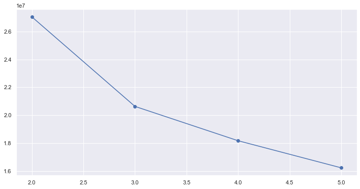

```python
# Elbow plot to ascertain the number of clusters

plt.figure(figsize=(12,6))
plt.plot( clusters_df.num_clusters, clusters_df.cluster_errors, marker = "o" )
```

The elbow method confirms that there are 3 good clusters in the dataset

```python
dataset_kmeans_scaled = dataset_kmeans.apply(zscore)

k_cluster = KMeans(n_clusters = 3, random_state = 1)
k_cluster.fit(dataset_kmeans_scaled)
dataset_kmeans_scaled['Cluster'] = k_cluster.predict(dataset_kmeans_scaled)
dataset_kmeans_scaled.head()
```

|  | cement | slag | ash | water | superplastic | coarseagg | fineagg | age | strength | water/cement | Cluster |
| --- | --- | --- | --- | --- | --- | --- | --- | --- | --- | --- | --- |
| 0 | -1.316792 | 1.650657 | -0.865375 | 1.043488 | -1.073740 | -0.033232 | -0.293557 | -0.148903 | -0.329328 | 2.191929 | 1 |
| 1 | -1.052152 | -0.342358 | 1.071486 | -1.204851 | 0.928248 | 1.372475 | 0.311909 | -0.655204 | -0.721299 | 0.576284 | 1 |
| 2 | -0.274530 | -0.837677 | 0.625836 | 0.242642 | -0.054209 | -0.225388 | 1.136968 | -0.148903 | -0.370491 | -0.026473 | 1 |
| 3 | -0.121115 | 0.500389 | -0.865375 | 2.262168 | -1.073740 | -0.546508 | -1.289973 | -0.148903 | 0.651214 | 0.318986 | 2 |
| 4 | -1.187348 | 1.314966 | -0.865375 | 0.536120 | 0.613121 | 0.941736 | -0.951065 | -0.148903 | -1.042003 | 1.576807 | 1 |

##### Analyzing the variance at attribute level

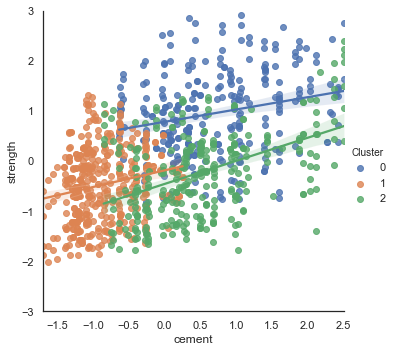

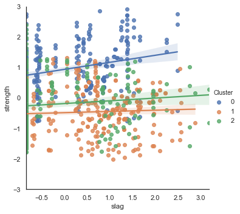

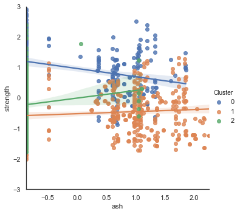

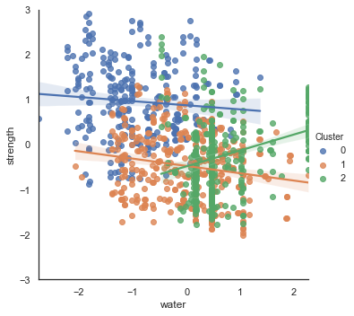

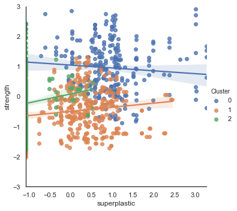

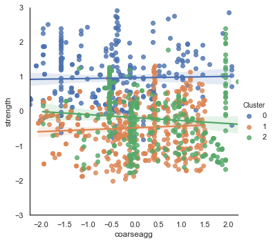

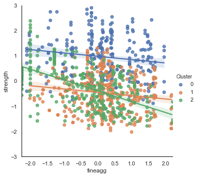

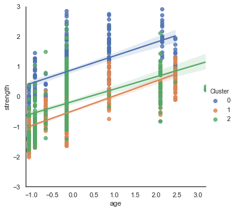

```python
columns = [i for i in dataset.columns if i not in ('strength','Cluster','water/cement')]
for col in columns:
    with sns.axes_style("white"):
        plot = sns.lmplot(col,'strength',data=dataset_kmeans_scaled, hue='Cluster')
    plot.set(ylim = (-3,3));
```

*Note that the more horizontal the line is, the weaker the independent variable is in predicting the target variable*

## Creating the model

We are going to train the following models using standard training and test data along with the PCA train and test data that we had captured in an earlier step.

- Linear Regression
- SVR
- Decision Tree
- Random Forest
- Ridge Regression
- Lasso Regression
- Bagging Regressor
- Ada Boost Regressor
- Gradient Boost Regressor

Feature importance can be done using Decision Tree regressor. We have done a feature importance activity with PCA where we identified 6 components that explain 95% of variance of the data

#### Train Test split

```python
dataset_scaled = dataset.apply(zscore)
X = dataset_scaled.drop('strength', axis = 'columns')
y = dataset_scaled['strength']
```

```python
X_train, X_test, y_train, y_test = train_test_split(X, y, test_size=0.3, random_state = 1)
```

### Linear Regression

```python
lr_model = LinearRegression()
lr_model.fit(X_train, y_train)
```

```
LinearRegression(copy_X=True, fit_intercept=True, n_jobs=None,
         normalize=False)
```

```python
lr_model_score = lr_model.score(X_test, y_test)
lr_model_score
```

```
0.6489182380175121
```

#### Linear Regression with PCA (reduced dimensionality)

```python
lr_model_pca = LinearRegression()
lr_model_pca.fit(X_train_pca, y_train_pca)
```

```
LinearRegression(copy_X=True, fit_intercept=True, n_jobs=None,
         normalize=False)
```

```python
lr_model_score_pca = lr_model_pca.score(X_test_pca, y_test_pca)
lr_model_score_pca
```

```
0.628557494676066
```

### SVM model

```python
svr_model = SVR()
svr_model.fit(X_train, y_train)
```

```
SVR(C=1.0, cache_size=200, coef0=0.0, degree=3, epsilon=0.1,
  gamma='auto_deprecated', kernel='rbf', max_iter=-1, shrinking=True,
  tol=0.001, verbose=False)
```

```python
svr_model_score = svr_model.score(X_test, y_test)
svr_model_score
```

```
0.8307635176906557
```

#### SVR with PCA (reduced dimensionality)

```python
svr_model_pca = SVR()
svr_model_pca.fit(X_train_pca, y_train_pca)
```

```
SVR(C=1.0, cache_size=200, coef0=0.0, degree=3, epsilon=0.1,
  gamma='auto_deprecated', kernel='rbf', max_iter=-1, shrinking=True,
  tol=0.001, verbose=False)
```

```python
svr_model_score_pca = svr_model_pca.score(X_test_pca, y_test_pca)
svr_model_score_pca
```

```
0.8133092071480776
```

### Ridge Regression

```python
ridge_model = Ridge(alpha=0.3)
ridge_model.fit(X_train, y_train)
```

```
Ridge(alpha=0.3, copy_X=True, fit_intercept=True, max_iter=None,
   normalize=False, random_state=None, solver='auto', tol=0.001)
```

```python
ridge_model_score = ridge_model.score(X_test, y_test)
ridge_model_score
```

```
0.6490412535204826
```

#### Ridge model with PCA (reduced dimensionality)

```python
ridge_model_pca = Ridge(alpha=0.3)
ridge_model_pca.fit(X_train_pca, y_train_pca)
```

```
Ridge(alpha=0.3, copy_X=True, fit_intercept=True, max_iter=None,
   normalize=False, random_state=None, solver='auto', tol=0.001)
```

```python
ridge_model_score_pca = ridge_model_pca.score(X_test_pca, y_test_pca)
ridge_model_score_pca
```

```
0.6285600235771389
```

### Lasso Regression

```python
lasso_model = Lasso(alpha=0.01)
lasso_model.fit(X_train, y_train)
```

```
Lasso(alpha=0.01, copy_X=True, fit_intercept=True, max_iter=1000,
   normalize=False, positive=False, precompute=False, random_state=None,
   selection='cyclic', tol=0.0001, warm_start=False)
```

```python
lasso_model_score = lasso_model.score(X_test, y_test)
lasso_model_score
```

```
0.6483209283715612
```

#### Lasso model with PCA (reduced dimensionality)

```python
lasso_model_pca = Lasso(alpha=0.01)
lasso_model_pca.fit(X_train_pca, y_train_pca)
```

```
Lasso(alpha=0.01, copy_X=True, fit_intercept=True, max_iter=1000,
   normalize=False, positive=False, precompute=False, random_state=None,
   selection='cyclic', tol=0.0001, warm_start=False)
```

```python
lasso_model_score_pca = lasso_model_pca.score(X_test_pca, y_test_pca)
lasso_model_score_pca
```

```
0.6288622476864292
```

### Decision Tree Regressor

```python
dt_model = DecisionTreeRegressor(max_depth=5, random_state=1)
dt_model.fit(X_train, y_train)
```

```
DecisionTreeRegressor(criterion='mse', max_depth=5, max_features=None,
           max_leaf_nodes=None, min_impurity_decrease=0.0,
           min_impurity_split=None, min_samples_leaf=1,
           min_samples_split=2, min_weight_fraction_leaf=0.0,
           presort=False, random_state=1, splitter='best')
```

```python
FI = dt_model.feature_importances_
Col_names=X_train.columns

summary = {'Features' : Col_names,'Feature Importance' : FI}

FI_df = pd.DataFrame(summary)
print('The feature importance is:','\n')
FI_df
```

```
The feature importance is:
```

|  | Features | Feature Importance |
| --- | --- | --- |
| 0 | cement | 0.005823 |
| 1 | slag | 0.096490 |
| 2 | ash | 0.007530 |
| 3 | water | 0.000000 |
| 4 | superplastic | 0.005849 |
| 5 | coarseagg | 0.007200 |
| 6 | fineagg | 0.005343 |
| 7 | age | 0.373831 |
| 8 | water/cement | 0.497934 |

Composite feature "water/cement" and feature "age" appear to be most important features among all

```python
dt_model_score = dt_model.score(X_test, y_test)
dt_model_score
```

```
0.6629538372268358
```

#### Decision Tree model with PCA (reduced dimensionality)

```python
dt_model_pca = DecisionTreeRegressor(max_depth=5, random_state=1)
dt_model_pca.fit(X_train_pca, y_train_pca)
```

```
DecisionTreeRegressor(criterion='mse', max_depth=5, max_features=None,
           max_leaf_nodes=None, min_impurity_decrease=0.0,
           min_impurity_split=None, min_samples_leaf=1,
           min_samples_split=2, min_weight_fraction_leaf=0.0,
           presort=False, random_state=1, splitter='best')
```

```python
dt_model_pca_score = dt_model_pca.score(X_test_pca, y_test_pca)
dt_model_pca_score
```

```
0.6046068729002005
```

### Random Forest Regressor

```python
rf_model = RandomForestRegressor(n_estimators=20, max_depth=5, random_state=1)
rf_model.fit(X_train, y_train)
```

```
RandomForestRegressor(bootstrap=True, criterion='mse', max_depth=5,
           max_features='auto', max_leaf_nodes=None,
           min_impurity_decrease=0.0, min_impurity_split=None,
           min_samples_leaf=1, min_samples_split=2,
           min_weight_fraction_leaf=0.0, n_estimators=20, n_jobs=None,
           oob_score=False, random_state=1, verbose=0, warm_start=False)
```

```python
rf_model_score = rf_model.score(X_test, y_test)
rf_model_score
```

```
0.7961607655073725
```

#### Random Forest model with PCA (reduced dimensionality)

```python
rf_model_pca = RandomForestRegressor(n_estimators=20, max_depth=5, random_state=1)
rf_model_pca.fit(X_train_pca, y_train_pca)
```

```
RandomForestRegressor(bootstrap=True, criterion='mse', max_depth=5,
           max_features='auto', max_leaf_nodes=None,
           min_impurity_decrease=0.0, min_impurity_split=None,
           min_samples_leaf=1, min_samples_split=2,
           min_weight_fraction_leaf=0.0, n_estimators=20, n_jobs=None,
           oob_score=False, random_state=1, verbose=0, warm_start=False)
```

```python
rf_model_score_pca = rf_model_pca.score(X_test_pca, y_test_pca)
rf_model_score_pca
```

```
0.7444835292620301
```

### Bagging Regressor

```python
helper = RandomForestRegressor(n_estimators=20, max_depth=5)
bag_model = BaggingRegressor(base_estimator=helper, n_estimators=200)
bag_model.fit(X_train, y_train)
```

```
BaggingRegressor(base_estimator=RandomForestRegressor(bootstrap=True, criterion='mse', max_depth=5,
           max_features='auto', max_leaf_nodes=None,
           min_impurity_decrease=0.0, min_impurity_split=None,
           min_samples_leaf=1, min_samples_split=2,
           min_weight_fraction_leaf=0.0, n_estimators=20, n_jobs=None,
           oob_score=False, random_state=None, verbose=0, warm_start=False),
         bootstrap=True, bootstrap_features=False, max_features=1.0,
         max_samples=1.0, n_estimators=200, n_jobs=None, oob_score=False,
         random_state=None, verbose=0, warm_start=False)
```

```python
bag_model_score = bag_model.score(X_test, y_test)
bag_model_score
```

```
0.7978377803645871
```

#### Bagging Regressor with PCA

```python
bag_model_pca = BaggingRegressor(base_estimator=helper, n_estimators=200)
bag_model_pca.fit(X_train_pca, y_train_pca)
```

```
BaggingRegressor(base_estimator=RandomForestRegressor(bootstrap=True, criterion='mse', max_depth=5,
           max_features='auto', max_leaf_nodes=None,
           min_impurity_decrease=0.0, min_impurity_split=None,
           min_samples_leaf=1, min_samples_split=2,
           min_weight_fraction_leaf=0.0, n_estimators=20, n_jobs=None,
           oob_score=False, random_state=None, verbose=0, warm_start=False),
         bootstrap=True, bootstrap_features=False, max_features=1.0,
         max_samples=1.0, n_estimators=200, n_jobs=None, oob_score=False,
         random_state=None, verbose=0, warm_start=False)
```

```python
bag_model_score_pca = bag_model_pca.score(X_test_pca, y_test_pca)
bag_model_score_pca
```

```
0.7452068338152895
```

### Adaptive Boosting Regressor

```python
adaboost_model = AdaBoostRegressor(base_estimator=helper, n_estimators=50)
adaboost_model.fit(X_train, y_train)
```

```
AdaBoostRegressor(base_estimator=RandomForestRegressor(bootstrap=True, criterion='mse', max_depth=5,
           max_features='auto', max_leaf_nodes=None,
           min_impurity_decrease=0.0, min_impurity_split=None,
           min_samples_leaf=1, min_samples_split=2,
           min_weight_fraction_leaf=0.0, n_estimators=20, n_jobs=None,
           oob_score=False, random_state=None, verbose=0, warm_start=False),
         learning_rate=1.0, loss='linear', n_estimators=50,
         random_state=None)
```

```python
adaboost_model_score = adaboost_model.score(X_test, y_test)
adaboost_model_score
```

```
0.8385108617811144
```

#### Adaboost with PCA

```python
adaboost_model_pca = AdaBoostRegressor(base_estimator=helper, n_estimators=50)
adaboost_model_pca.fit(X_train_pca, y_train_pca)
```

```
AdaBoostRegressor(base_estimator=RandomForestRegressor(bootstrap=True, criterion='mse', max_depth=5,
           max_features='auto', max_leaf_nodes=None,
           min_impurity_decrease=0.0, min_impurity_split=None,
           min_samples_leaf=1, min_samples_split=2,
           min_weight_fraction_leaf=0.0, n_estimators=20, n_jobs=None,
           oob_score=False, random_state=None, verbose=0, warm_start=False),
         learning_rate=1.0, loss='linear', n_estimators=50,
         random_state=None)
```

```python
adaboost_model_score_pca = adaboost_model_pca.score(X_test_pca, y_test_pca)
adaboost_model_score_pca
```

```
0.7853041276943882
```

### Gradient Boosting Regressor

```python
gboost_model = GradientBoostingRegressor(n_estimators=500, max_depth=5, random_state=1, learning_rate=.5)
gboost_model.fit(X_train, y_train)
```

```
GradientBoostingRegressor(alpha=0.9, criterion='friedman_mse', init=None,
             learning_rate=0.5, loss='ls', max_depth=5, max_features=None,
             max_leaf_nodes=None, min_impurity_decrease=0.0,
             min_impurity_split=None, min_samples_leaf=1,
             min_samples_split=2, min_weight_fraction_leaf=0.0,
             n_estimators=500, n_iter_no_change=None, presort='auto',
             random_state=1, subsample=1.0, tol=0.0001,
             validation_fraction=0.1, verbose=0, warm_start=False)
```

```python
gboost_model_score = gboost_model.score(X_test, y_test)
gboost_model_score
```

```
0.9095568209277349
```

#### Gradient Boosting Regressor with PCA

```python
gboost_model_pca = GradientBoostingRegressor(n_estimators=500, max_depth=5, random_state=1, learning_rate=.5)
gboost_model_pca.fit(X_train_pca, y_train_pca)
```

```
GradientBoostingRegressor(alpha=0.9, criterion='friedman_mse', init=None,
             learning_rate=0.5, loss='ls', max_depth=5, max_features=None,
             max_leaf_nodes=None, min_impurity_decrease=0.0,
             min_impurity_split=None, min_samples_leaf=1,
             min_samples_split=2, min_weight_fraction_leaf=0.0,
             n_estimators=500, n_iter_no_change=None, presort='auto',
             random_state=1, subsample=1.0, tol=0.0001,
             validation_fraction=0.1, verbose=0, warm_start=False)
```

```python
gboost_model_score_pca = gboost_model_pca.score(X_test_pca, y_test_pca)
gboost_model_score_pca
```

```
0.8343381702586657
```

## Tuning the Model

### Identifying Algorithms suitable for this project

```python
compare = [[lr_model_score, lr_model_score_pca],
           [svr_model_score, svr_model_score_pca],
           [ridge_model_score, ridge_model_score_pca],
           [lasso_model_score, lasso_model_score_pca],
           [dt_model_score, dt_model_pca_score],
           [rf_model_score, rf_model_score_pca],
           [bag_model_score, bag_model_score_pca],
           [adaboost_model_score, adaboost_model_score_pca],
           [gboost_model_score, gboost_model_score_pca]
          ]
```

```python
legend = ['Linear Reg', 'SVR', 'Ridge', 'Lasso', 'Decision Tree', 'Random Forest','Bagging', 'AdaBoost', 'Grad Boost']
columns = ['Accuracy Score', 'Accuracy score (with PCA)']
pd.DataFrame(data=compare,columns=columns, index=legend)
```

|  | Accuracy Score | Accuracy score (with PCA) |
| --- | --- | --- |
| Linear Reg | 0.648918 | 0.628557 |
| SVR | 0.830764 | 0.813309 |
| Ridge | 0.649041 | 0.628560 |
| Lasso | 0.648321 | 0.628862 |
| Decision Tree | 0.662954 | 0.604607 |
| Random Forest | 0.796161 | 0.744484 |
| Bagging | 0.797838 | 0.745207 |
| AdaBoost | 0.838511 | 0.785304 |
| Grad Boost | 0.909557 | 0.834338 |

```python
scores = [lr_model_score, svr_model_score, ridge_model_score, lasso_model_score, dt_model_score, rf_model_score,
          bag_model_score, adaboost_model_score, gboost_model_score]
scores_pca = [lr_model_score_pca, svr_model_score_pca, ridge_model_score_pca, lasso_model_score_pca, dt_model_pca_score,
              rf_model_score_pca, bag_model_score_pca, adaboost_model_score_pca, gboost_model_score_pca]
```

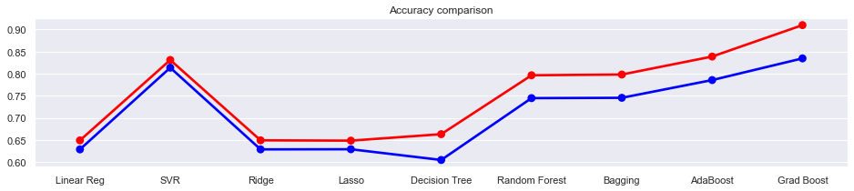

```python
plt.figure(figsize=(16, 3))
plt.title('Accuracy comparison')

sns.pointplot(legend, scores, color = 'red', label = 'Accuracy')
sns.pointplot(legend, scores_pca, color ='blue', label = 'Accuracy (with PCA)')
```

*Accuracy scores of Grad boosting algorithm is the hightest as seen from the plot above. We also observe that the drop in accuracy scores when reducing dimensions through PCA is more significant in ensemles and DT as compared to Linear regression, Ridge, Lasso and SVR. The max drop is however, also observed in Grad boost regression.*

### Techniques employed to squeeze that extra performance out of the model without making it overfit or underfit

We will the technique of grid search to get that extra performance from the model. Since the best performing model is Gradient Boost; hence the technique will be applied on it.

```python
regressor = GradientBoostingRegressor()
```

```python
regressor.get_params
```

```
<bound method BaseEstimator.get_params of GradientBoostingRegressor(alpha=0.9, criterion='friedman_mse', init=None,
             learning_rate=0.1, loss='ls', max_depth=3, max_features=None,
             max_leaf_nodes=None, min_impurity_decrease=0.0,
             min_impurity_split=None, min_samples_leaf=1,
             min_samples_split=2, min_weight_fraction_leaf=0.0,
             n_estimators=100, n_iter_no_change=None, presort='auto',
             random_state=None, subsample=1.0, tol=0.0001,
             validation_fraction=0.1, verbose=0, warm_start=False)>
```

```python
search_grid = {'n_estimators':[100,200,300,400,500,600],'learning_rate':[.001,0.01,.1],'max_depth':[1,2,3,4,5],
             'subsample':[.5,.75,1],'random_state':[1]}
gs_CV = GridSearchCV(estimator=regressor, param_grid=search_grid, scoring='neg_mean_squared_error', n_jobs=1, cv=10)
```

```python
gs_CV.fit(X_train,y_train)
gs_CV.best_params_
```

```
{'learning_rate': 0.1,
 'max_depth': 4,
 'n_estimators': 300,
 'random_state': 1,
 'subsample': 0.75}
```

We can now build a Gradient Boost model with the above identified parameters

```python
reg = GradientBoostingRegressor(learning_rate=0.1, max_depth=4, n_estimators=300, random_state=1, subsample=0.75)
reg.fit(X_train, y_train)
```

```
GradientBoostingRegressor(alpha=0.9, criterion='friedman_mse', init=None,
             learning_rate=0.1, loss='ls', max_depth=4, max_features=None,
             max_leaf_nodes=None, min_impurity_decrease=0.0,
             min_impurity_split=None, min_samples_leaf=1,
             min_samples_split=2, min_weight_fraction_leaf=0.0,
             n_estimators=300, n_iter_no_change=None, presort='auto',
             random_state=1, subsample=0.75, tol=0.0001,
             validation_fraction=0.1, verbose=0, warm_start=False)
```

```python
reg.score(X_test, y_test)
```

```
0.9250571323050105
```

We can observe that the model performance improved by 2% using the Grid Search technique

### Model performance range at 95% confidence level

```python
cvscores = cross_val_score(reg, X, y, cv = 10)
```

```python
CV_score_mean = cvscores.mean()
CV_score_std = cvscores.std()

print("The mean score value is:", CV_score_mean, " and the std is:", CV_score_std)
```

```
The mean score value is: 0.9236294910303802  and the std is: 0.03050275844195084
```

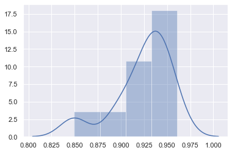

```python
sns.distplot(cvscores)
```

For the scores in the range mean (+-) 2*std we can be certain of the scores with 95% confidence

```python
print("Range of scores for 95% confidence is {} and {}".format((CV_score_mean-2*CV_score_std),
                                                               (CV_score_mean+2*CV_score_std)))
```

```
Range of scores for 95% confidence is 0.8626239741464785 and 0.9846350079142818
```

We can assure with 95% confidence that the accuracy scores of gradient boost regressor with hyper parameters (learning_rate=0.1, max_depth=4, n_estimators=300, random_state=1, subsample=0.75) will have a accuracy of 86.2% and 98.4%